# Processar

2021-06-18

[figure not shown]

# Processar

*O processamento de alimentos é necessário para a **transformação** de ingredientes brutos em novos ingredientes.*

#### Resumo

- O processamento de alimentos pode ser realizado nas fogueiras e nos fogões;
- 12 ingredientes podem ser processados a partir de outros ingredientes;
- Não é possível `cancelar` o processamento, uma vez que você já tenha iniciado;
- Lembre-se de acender a fogueira, e;
- A fila de processamento é de 99 itens.

Atualmente a função `processar` presente na função `culinária` pode gerar 12 novos ingredientes, das quais serão utilizados na elaboração de outros pratos.

O processamento de alimentos **não é imediato** , desta forma cada novo ingrediente possui um tempo de preparo.

##### Tabela de Processos de Ingredientes

A tabela abaixo apresenta um resumo para a produção do produto desejado e a sua respectiva quantidade de ingredientes.

Produto

Ranking

Duração [minutos]

Ingredientes

[figure not shown]

Farinha

1

[figure not shown]

Carne Crua

1

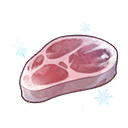

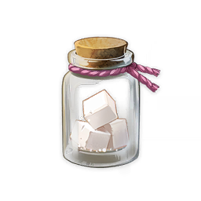

Açúcar

3

[figure not shown]

[figure not shown]

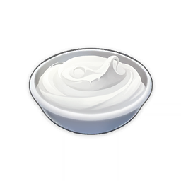

Creme

3

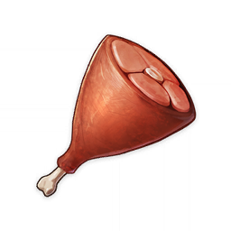

Carne de Ave Defumada

5

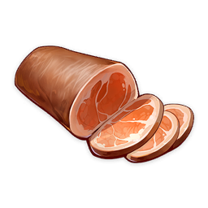

Presunto

5

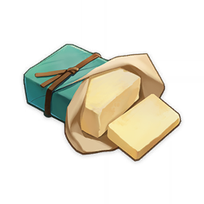

Manteiga

5

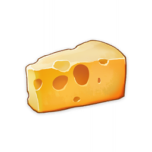

Queijo

10

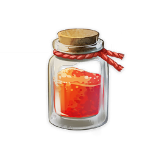

Geleia

10

[figure not shown]

[figure not shown]

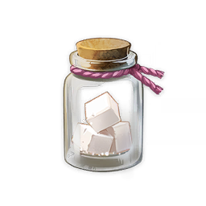

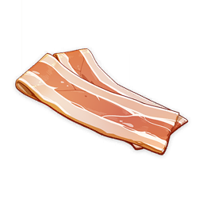

Bacon

15

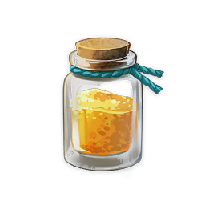

Ovas de Caranguejo

20

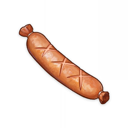

Salsicha

20

##### Fila de Processamento

O `processamento` possui uma fila de execução de trabalhos de até **99 slots**, onde cada ingrediente será produzido de maneira unitária.

Preste atenção com a fila de execução, pois **não é possível cancelar** o processamento de ingredientes.